# Graduation rates report

Feifan Cao, Chuxiao Yu

12/4/2022

```r
#all the packages we used in this project
library(ggplot2)
library(dplyr)
library(lubridate)
library(patchwork)
library(hrbrthemes)
```

## Introduction

In this project, we are interested in if graduation rate related to different district and different year in Iowa. We got our data from https://data.iowa.gov/Primary-Secondary-Ed/4-Year-Graduation-Rates-in-Iowa-by-Cohort-and-Publ/tqti-3w6t.This dataset provides the 4-Year graduation rates in Iowa by cohort (represented by graduating class) and public school district starting with the Class of 2009.

```r
df=read.csv("4-Year_Graduation_Rates_in_Iowa_by_Cohort_and_Public_School_District.csv")
```

## Data

```r
dim(df)
```

```
## [1] 3566    8
```

```r
variable.names(df)
```

```
## [1] "Graduating.Class"         "Fall.Freshman.Year"
## [3] "District"                 "District.Name"
## [5] "Graduates"                "Total.Cohort"
## [7] "Graduation.Rate"          "Graduation.Rate.Category"
```

```r
length(unique(df$District))
```

```
## [1] 348
```

```r
length(unique(df$District.Name))
```

```
## [1] 378
```

```r
range(df$Graduating.Class)
```

```
## [1] 2009 2019
```

There are 3566 rows with 8 columns in our data set. Here are the introductions for each variable:

Graduating Class - Year the class is expected to graduate. We can see that the graduation year is from 2009 to 2019.

Fall Freshman Year - The year the cohort entered their freshman year of high school

District - ID given by the Department of Education for the school district. There are 348 different district ID in total.

District Name - Name of the school district. There are 378 different district names in total. There is more District Name(`District.Name`) than the district ID(`District`) we assume there are some district names share the same district ID or maybe the district name have been changed during 2009-2019 but using the same District ID.

Graduates - First time freshman in year indicated in fall freshman year and transfers into the cohort in grades 9 to 12 who graduated in year indicated in graduating class or earlier.

Total Cohort - First time freshman in year indicated in fall freshman year and transfers into the cohort in grades 9 to 12 less those who transferred out (including deceased).

Graduation Rate - Graduates divided by Total Cohort multiplied by 100.

## Clean the data set

```r
gr=na.omit(df)
head(gr)
```

```
##    Graduating.Class Fall.Freshman.Year District District.Name Graduates
## 5              2014               2010     5160           PCM        65
## 7              2010               2006     5160           PCM        74
## 8              2013               2009      171          Alta        51
## 9              2017               2013     2727 Grundy Center        53
## 10             2014               2010     1503       Creston       101
## 12             2009               2005     4725        Newton       220
##    Total.Cohort Graduation.Rate Graduation.Rate.Category
## 5            70            92.9              90.1 - 100%
## 7            86            86.1               80.1 - 90%
## 8            51           100.0              90.1 - 100%
## 9            53           100.0              90.1 - 100%
## 10          111            91.0              90.1 - 100%
## 12          254            86.6               80.1 - 90%
```

```r
dim(gr)
```

```
## [1] 3458    8
```

## Graphs

We would like to use Graduation Rate as our dependent variable and we would like to analysis different district and freshman year based on the graphs.

In the first graph, we are interested in if there is relationship between district and graduation rate. We use group_by function to summarize the the variable `District`, and then we use summarize and mutate function to find the mean graduation rate of year 2009-2019. In the end, we draw a bar plot for of different District and mean Graduation rate.

Based on the output graph, it is too concentrated to tell if there is any relationship between district and graduation rate.

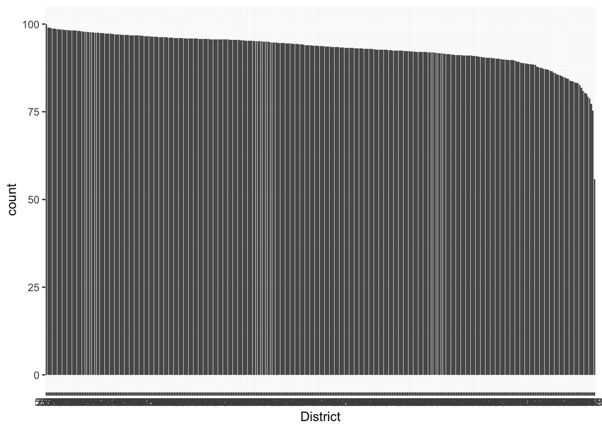

```r
gr %>%
  group_by(District) %>%
  summarize(Graduation.Rate= mean(Graduation.Rate)) %>%
  mutate(District= reorder(District, -Graduation.Rate, mean)) %>%
  ggplot(aes(District, weight=Graduation.Rate)) + geom_bar()
```

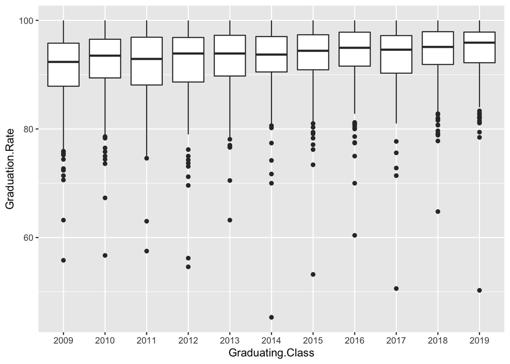

```r
gr$Graduating.Class=as.character(gr$Graduating.Class)
gr %>%
  group_by(Graduating.Class) %>%
  ggplot(aes(Graduating.Class,y=Graduation.Rate))+geom_boxplot()
```

## Ames

We are interested in the graduation rate and total cohort in Ames and we created the following graphs. And we can see that 2018 has the highest graduation rate and 2010 has the lowest graduation rate. We can also conclude that for Ames, there is no interaction between Graduating class, total cohort or graduation rate.

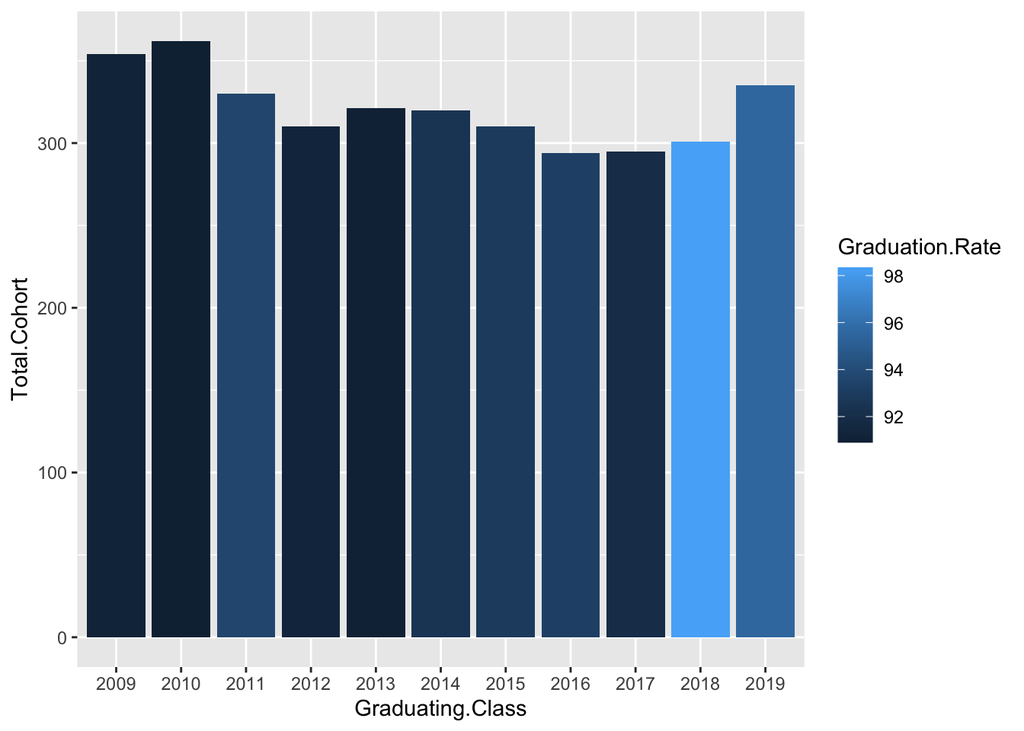

```r
ames=gr%>%filter(District.Name=="Ames")%>%
  group_by(Graduating.Class)

ames%>%ggplot(aes(x=Graduating.Class, y=Total.Cohort, fill=Graduation.Rate))+geom_bar(stat="identity")
```

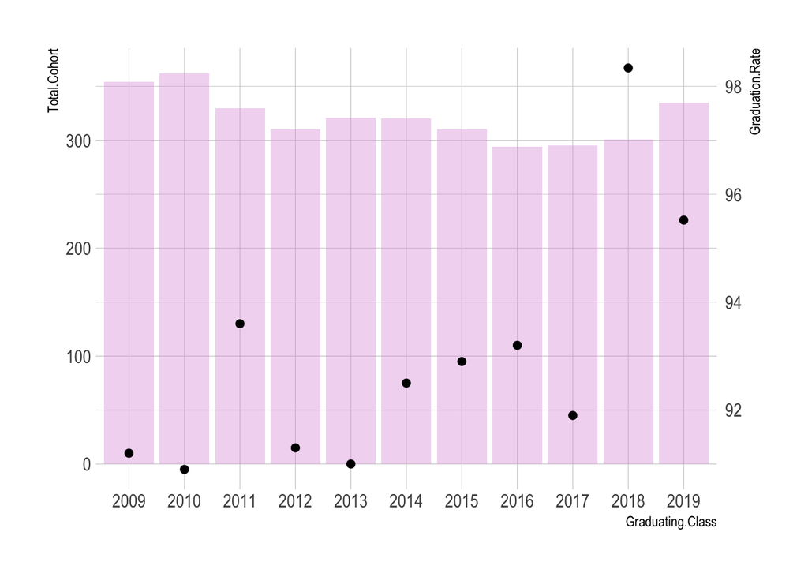

```r
ggplot(ames, aes(x=Graduating.Class)) +
 geom_bar( aes(y=Total.Cohort), stat="identity", size=.1, fill="plum", alpha=.4)+
  geom_point(aes(y=(Graduation.Rate-91)*50), size=2) +
  scale_y_continuous(
    name = "Total.Cohort",
    sec.axis = sec_axis( trans=~./50+91, name="Graduation.Rate")
  ) +theme_ipsum()
```

## Related Data Set 2

### Intro and data cleaning

In the first part of the code, we are introducing the data, change all the N/A and empty cell into NA, and delete all the NA values for further research. We also change the data type to what they are supposed to be. The final data set is saved as gi.After cleaning the data, we can see that there are 1859 rows with 15 columns.

```r
df3 <- read.csv("graduate_intention.csv")
#change all the N/A and empty cell into NA and delete them
df3[df3 == ""] <- NA
df3[df3 == "N/A"] <- NA
gi=na.omit(df3)
variable.names(gi)
```

```
##  [1] "County"                 "AEA"                    "District"
##  [4] "District.Name"          "Graduation.Year"        "Diploma.Count"
##  [7] "Private.4.Year.College" "Public.4.Year.College"  "Private.2.Year.College"
## [10] "Community.College"      "Other.Training"         "Employment"
## [13] "Homemaker"              "Military"               "Unknown"
```

```r
str(gi)
```

```
## 'data.frame':    1863 obs. of  15 variables:
##  $ County                : int  42 39 25 75 68 57 55 3 12 11 ...
##  $ AEA                   : int  7 11 11 12 15 10 5 1 7 5 ...
##  $ District              : int  9 18 27 63 81 99 126 135 153 171 ...
##  $ District.Name         : chr  "AGWSR" "Adair-Casey" "Adel DeSoto Minburn" "Akron Westfield" ...
##  $ Graduation.Year       : int  2012 2012 2012 2012 2012 2012 2012 2012 2012 2012 ...
##  $ Diploma.Count         : chr  "51" "34" "94" "42" ...
##  $ Private.4.Year.College: chr  "8" "2" "6" "6" ...
##  $ Public.4.Year.College : chr  "12" "7" "44" "18" ...
##  $ Private.2.Year.College: chr  "24" "15" "25" "10" ...
##  $ Community.College     : chr  "0" "0" "3" "0" ...
##  $ Other.Training        : chr  "0" "4" "4" "1" ...
##  $ Employment            : chr  "4" "5" "7" "6" ...
##  $ Homemaker             : chr  "0" "0" "0" "0" ...
##  $ Military              : chr  "1" "1" "5" "1" ...
##  $ Unknown               : chr  "2" "0" "0" "0" ...
##  - attr(*, "na.action")= 'omit' Named int [1:171] 5 8 15 22 32 70 88 94 102 115 ...
##   ..- attr(*, "names")= chr [1:171] "5" "8" "15" "22" ...
```

```r
gi$Diploma.Count=as.numeric(gi$Diploma.Count)
gi$Private.4.Year.College=as.numeric(gi$Private.4.Year.College)
gi$Public.4.Year.College=as.numeric(gi$Public.4.Year.College)
gi$Private.2.Year.College=as.numeric(gi$Private.2.Year.College)
gi$Community.College=as.numeric(gi$Community.College)
gi$Other.Training=as.numeric(gi$Other.Training)
gi$Employment=as.numeric(gi$Employment)
gi$Homemaker=as.numeric(gi$Homemaker)
gi$Military=as.numeric(gi$Military)
gi$Unknown=as.numeric(gi$Unknown)
gi$Graduation.Year=as.character(gi$Graduation.Year)
str(gi)
```

```
## 'data.frame':    1863 obs. of  15 variables:
##  $ County                : int  42 39 25 75 68 57 55 3 12 11 ...
##  $ AEA                   : int  7 11 11 12 15 10 5 1 7 5 ...
##  $ District              : int  9 18 27 63 81 99 126 135 153 171 ...
##  $ District.Name         : chr  "AGWSR" "Adair-Casey" "Adel DeSoto Minburn" "Akron Westfield" ...
##  $ Graduation.Year       : chr  "2012" "2012" "2012" "2012" ...
##  $ Diploma.Count         : num  51 34 94 42 74 52 97 100 43 56 ...
##  $ Private.4.Year.College: num  8 2 6 6 3 5 11 19 12 11 ...
##  $ Public.4.Year.College : num  12 7 44 18 23 18 29 17 8 11 ...
##  $ Private.2.Year.College: num  24 15 25 10 41 27 46 42 16 23 ...
##  $ Community.College     : num  0 0 3 0 0 0 0 0 0 0 ...
##  $ Other.Training        : num  0 4 4 1 0 0 3 3 2 0 ...
##  $ Employment            : num  4 5 7 6 6 2 5 16 5 4 ...
##  $ Homemaker             : num  0 0 0 0 0 0 0 0 0 0 ...
##  $ Military              : num  1 1 5 1 1 0 2 2 0 7 ...
##  $ Unknown               : num  2 0 0 0 0 0 1 1 0 0 ...
##  - attr(*, "na.action")= 'omit' Named int [1:171] 5 8 15 22 32 70 88 94 102 115 ...
##   ..- attr(*, "names")= chr [1:171] "5" "8" "15" "22" ...
```

```r
gi=na.omit(gi)
dim(gi)
```

```
## [1] 1859   15
```

### basic analysis

Next, we would like to some basic analysis for this data.

According to the output, we can see that most students will go to college(private 4 year college, public 4 year college, private 2 year college and community college) after they graduate. Employement is another popular choice for students who graduate from high school.

```r
gi%>%group_by(Graduation.Year)%>%
  summarize(
    sum.Diploma.Count=sum(Diploma.Count),
    sum.Private.4.Year.College=sum(Private.4.Year.College),
    sum.Public.4.Year.College=sum(Public.4.Year.College),
    sum.Private.2.Year.College=sum(Private.2.Year.College),
    sum.Community.College=sum(Community.College),
    sum.Other.Training=sum(Other.Training),
    sum.Employment=sum(Employment),
    sum.Homemaker=sum(Homemaker),
    sum.Military=sum(Military),
    sum.Unknown=sum(Unknown)
  )
```

```
## # A tibble: 6 × 11
##   Graduation.Y…¹ sum.D…² sum.P…³ sum.P…⁴ sum.P…⁵ sum.C…⁶ sum.O…⁷ sum.E…⁸ sum.H…⁹
##   <chr>            <dbl>   <dbl>   <dbl>   <dbl>   <dbl>   <dbl>   <dbl>   <dbl>
## 1 2012             32548    4204    8681   12264     296     766    2948      61
## 2 2013             32920    4188    8869   12430     252     779    3300      39
## 3 2014             32748    4068    9013   12221     201     738    3306      47
## 4 2015             33003    3650    9542   12158     176     797    3474      54
## 5 2016             30124    3475    8583   11054     169     795    3391      43
## 6 2017             30782    3537    8688   11081     159     741    3675      24
## # … with 2 more variables: sum.Military <dbl>, sum.Unknown <dbl>, and
## #   abbreviated variable names ¹Graduation.Year, ²sum.Diploma.Count,
## #   ³sum.Private.4.Year.College, ⁴sum.Public.4.Year.College,
## #   ⁵sum.Private.2.Year.College, ⁶sum.Community.College, ⁷sum.Other.Training,
## #   ⁸sum.Employment, ⁹sum.Homemaker
```

According to the graph graduation.year versus diploma count below, we can see that graduation is not a factor that affects diploma count.

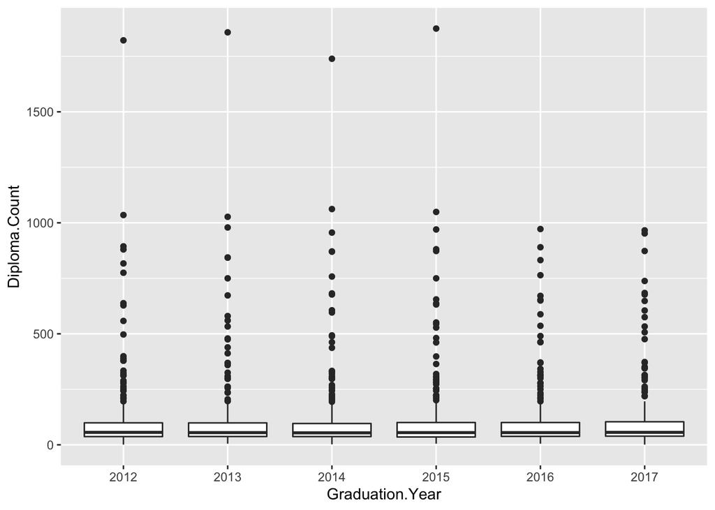

```r
ggplot(gi,aes(x=Graduation.Year, y=Diploma.Count))+geom_boxplot()
```

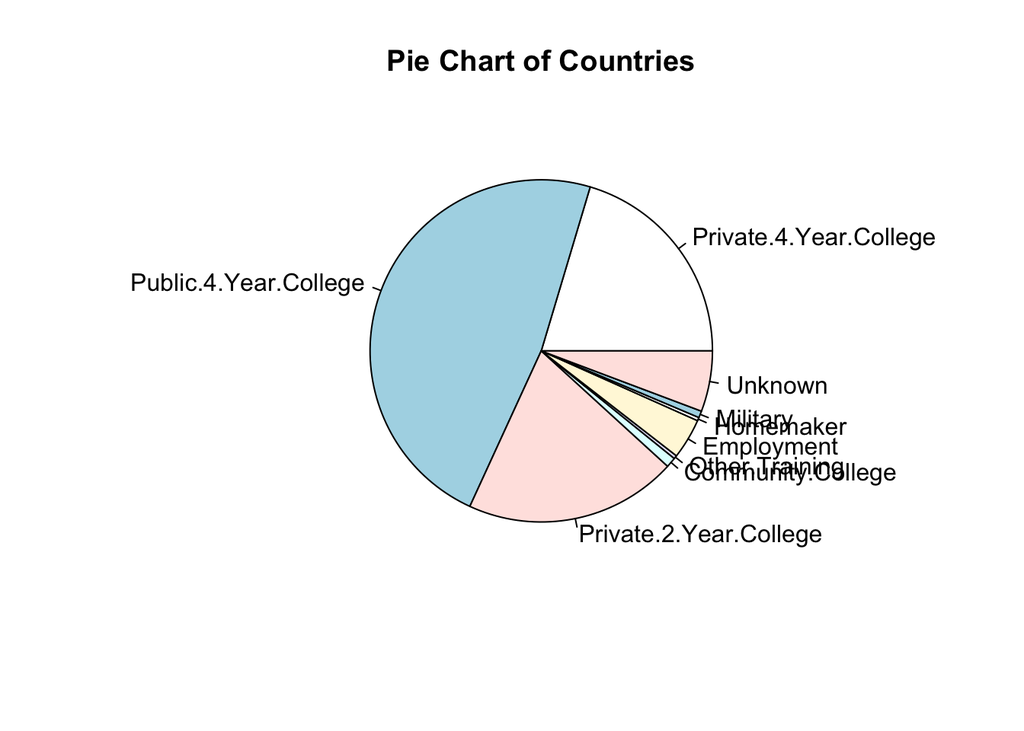

```r
ames2=gi%>%filter(District.Name=="Ames")%>%group_by(Graduation.Year)
#2012
slices12=c(64, 150, 63, 3, 1, 12, 1, 2, 18)
lbls12=c("Private.4.Year.College", "Public.4.Year.College", "Private.2.Year.College", "Community.College", "Other.Training","Employment", "Homemaker",  "Military", "Unknown" )
pie(slices12, labels = lbls12, main="Pie Chart of Countries")
```

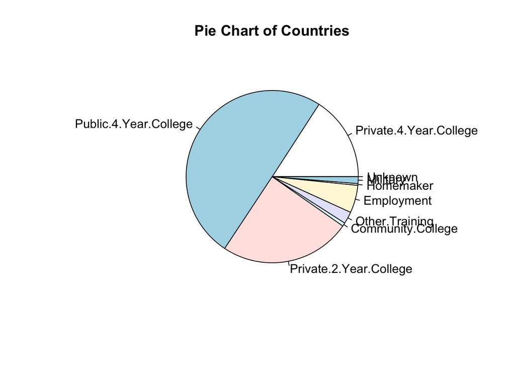

```r
#2013
slices13=c(49, 154, 76, 2, 7, 16, 1, 4, 0)
lbls13=c("Private.4.Year.College", "Public.4.Year.College", "Private.2.Year.College", "Community.College", "Other.Training","Employment", "Homemaker",  "Military", "Unknown" )
pie(slices13, labels = lbls13, main="Pie Chart of Countries")
```